# HPP: COVID-19

Ana Paula Pacheco, Carolina Prando e [Henrique Laureano](https://henriquelaureano.github.io/)

Last modification on* 2022-09-29 14:20:25

# Carga Viral

```
                  Alta      Baixa     Média     NI
[1,] "Total"      "442"     "154"     "214"     "218"
[2,] "Percentual" "42.996%" "14.981%" "20.817%" "21.206%"
```

```
[1] 7.294513e-38
```

> p-valor altamente significativo indicando diferença significativa entre as frequências de carga viral alta, média e baixa.

# Classificação

```
                  ASSINTOMÁTICO OUTRO     SIM-P   SINT DIGESTIVO SINT RESP SRAG
[1,] "Total"      "33"          "199"     "11"    "104"          "574"     "107"
[2,] "Percentual" "3.21%"       "19.358%" "1.07%" "10.117%"      "55.837%" "10.409%"
```

# Sexo

```
                  Feminino  Masculino
[1,] "Total"      "462"     "566"
[2,] "Percentual" "44.942%" "55.058%"
```

```
[1] 0.00118
```

> p-valor significativo indicando diferença significativa entre as frequências de meninas e meninos com COVID-!9.

# Etnia

```
                  Amarela  Branca    NR        Parda
[1,] "Total"      "1"      "175"     "331"     "21"
[2,] "Percentual" "0.189%" "33.144%" "62.689%" "3.977%"
```

# Idade

```
# A tibble: 1 × 7
  Mínimo `1o.quantil` Mediana `3o.quantil` Máximo Media Desvio.Padrão
   <dbl>        <dbl>   <dbl>        <dbl>  <dbl> <dbl>         <dbl>
1      0         1.86    6.29         11.4   17.8  6.89          5.15
```

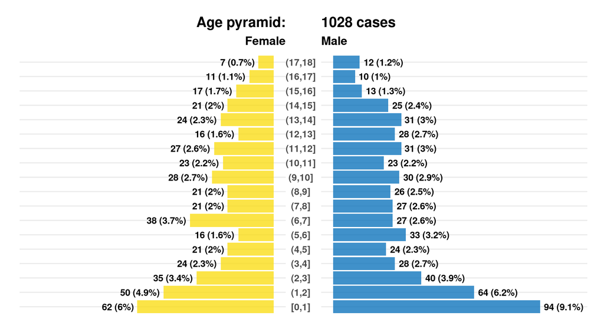

```
# A tibble: 2 × 8
  Sexo      Mínimo `1o.quantil` Mediana `3o.quantil` Máximo Media Desvio.Padrão
  <fct>      <dbl>        <dbl>   <dbl>        <dbl>  <dbl> <dbl>         <dbl>
1 Feminino  0.0137         2.09    6.57         11.4   17.8  7.06          5.10
2 Masculino 0              1.77    6.00         11.4   17.8  6.75          5.20
```

```
[1] 0.3455367
```

> Diferença média das idades por sexo não difere significativamente.

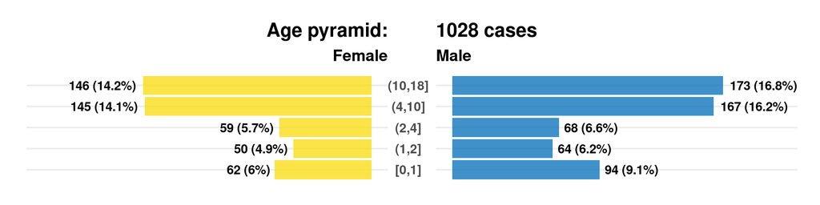

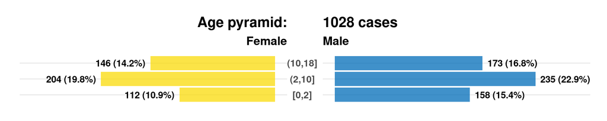

## Idade e comorbidade

```
# A tibble: 2 × 8
  `PRESENÇA DE COMORBIDADE` Mínimo `1o.quantil` Mediana `3o.quantil` Máximo Media Desvio.Padrão
                      <dbl>  <dbl>        <dbl>   <dbl>        <dbl>  <dbl> <dbl>         <dbl>
1                         0 0              1.73    6.23         10.8   17.8  6.64          5.07
2                         1 0.0465         3.45    7.22         12.8   17.8  8.05          5.38
```

```
[1] 0.001293321
```

> Diferença média das idades por presença de comorbidade difere significativamente.

## Idade e internação

```
# A tibble: 2 × 8
  Internou Mínimo `1o.quantil` Mediana `3o.quantil` Máximo Media Desvio.Padrão
     <dbl>  <dbl>        <dbl>   <dbl>        <dbl>  <dbl> <dbl>         <dbl>
1        0 0              2.16    6.59         11.1   17.8  6.98          4.98
2        1 0.0137         1.07    5.42         12.3   17.7  6.51          5.80
```

```
[1] 0.2849052
```

> Diferença média das idades por internação não difere significativamente.

```
# A tibble: 3 × 8
  Grupo        Mínimo `1o.quantil` Mediana `3o.quantil` Máximo Media Desvio.Padrão
  <chr>         <dbl>        <dbl>   <dbl>        <dbl>  <dbl> <dbl>         <dbl>
1 Internou enf 0.0137        0.874    3.66         12.2   17.7  6.30          5.83
2 Internou UTI 0.0192        1.38     5.78         13.1   17.2  7.02          5.74
3 Não internou 0             2.16     6.59         11.1   17.8  6.98          4.98
```

```
# A tibble: 3 × 2
  ` `                           `valor-p`
  <chr>                             <dbl>
1 Não internou vs. Internou enf     0.186
2 Não internou vs. Internou UTI     0.963
3 Internou enf vs. Internou UTI     0.418
```

> As diferenças médias das idades não diferem significativamente.

# Município

```
# A tibble: 45 × 2
   Município                 n
   <fct>                 <int>
 1 CURITIBA                659
 2 SÃO JOSÉ DOS PINHAIS     84
 3 COLOMBO                  59
 4 PIRAQUARA                26
 5 ALMIRANTE TAMANDARÉ      25
 6 ARAUCÁRIA                25
 7 PINHAIS                  25
 8 FAZENDA RIO GRANDE       24
 9 CAMPO LARGO              20
10 CAMPINA GRANDE DO SUL    10
11 PARANAGUÁ                 9
12 QUATRO BARRAS             7
```

[output cut: 33 more lines]

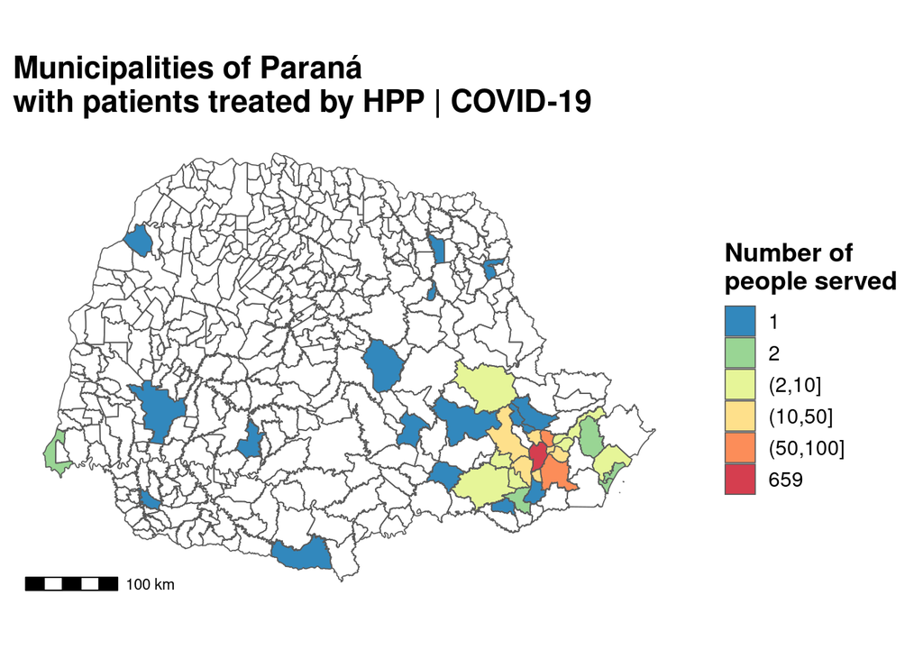

# Alta

```
                  Alta      Não internou Óbito    Transferência
[1,] "Total"      "193"     "824"        "9"      "2"
[2,] "Percentual" "18.774%" "80.156%"    "0.875%" "0.195%"
```

# Resultado COVID

```
                  DETECTÁVEL DETECTÁVEL/EXTERNO POSITIVO REAGENTE
[1,] "Total"      "960"      "3"                "46"     "19"
[2,] "Percentual" "93.385%"  "0.292%"           "4.475%" "1.848%"
```

# Comorbidade

## Presença

```
                  0         1
[1,] "Total"      "845"     "183"
[2,] "Percentual" "82.198%" "17.802%"
```

```
[1] 1.034169e-94
```

> p-valor altamente significativo. Existe uma diferença significativa entre a quantidade de pacientes com e sem comorbidades.

## Comorbidades

[figure not shown]

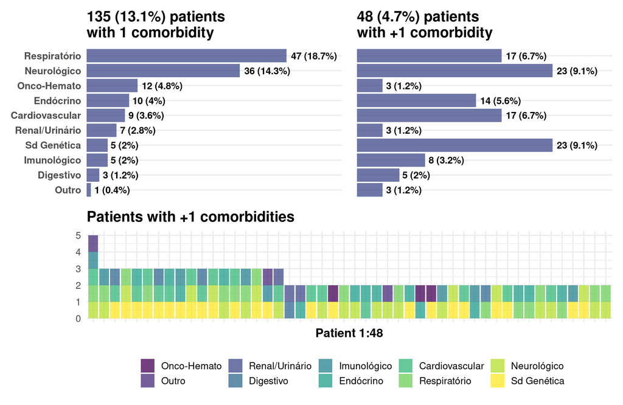

## Quantas comorbidades

```
                  0         1         2        3        5
[1,] "Total"      "845"     "135"     "30"     "17"     "1"
[2,] "Percentual" "82.198%" "13.132%" "2.918%" "1.654%" "0.097%"
```

## Comorbidade por internação

```
# A tibble: 2 × 3
  `PRESENÇA DE COMORBIDADE` `Internou: 0` `Internou: 1`
                      <dbl>         <int>         <int>
1                         0           749            96
2                         1            75           108
```

```
[1] 5.611713e-48
```

> Existe uma interação significativa entre presença de comorbidade e internação, valor-*p* < 0.0001.

> Quando analisamos apenas as crianças internadas, a presença de comorbidade não se mostrou estatisticamente significativa (valor-*p* de 0.4). Contudo, aqui é. Ou seja, entre as crianças sem comorbidade, a probabilidade de não ser internada é maior, significativa. Entre as crianças com comorbidade, a internação é o eventro de maior probabilidade.

# Data do início dos sintomas

```
                  ASSINTOMÁTICO NÃO DISPONÍVEL
[1,] "Total"      "33"          "126"
[2,] "Percentual" "20.755%"     "79.245%"
```

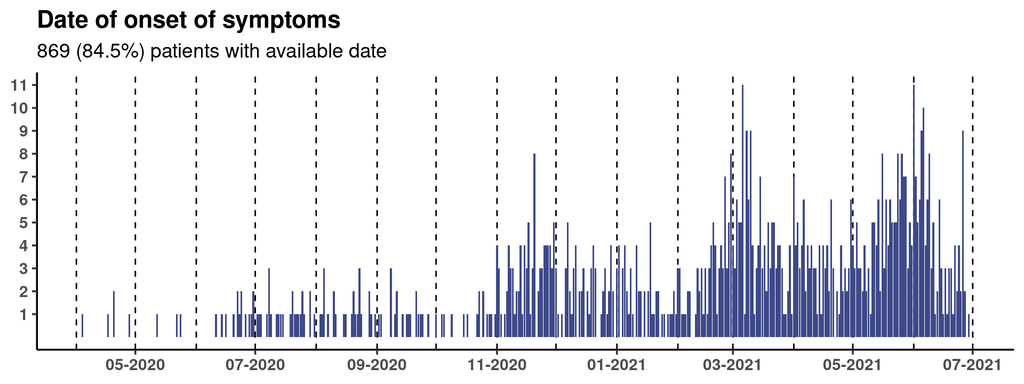

```
      Mínimo   1o.quantil      Mediana        Média   3o.quantil       Máximo
"2020-04-04" "2020-12-14" "2021-03-10" "2021-02-19" "2021-05-14" "2021-06-29"
```

```
Desvio.Padrão
     97.99593
```

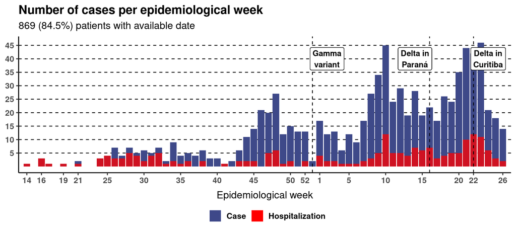

> Número de casos por semana epidemiológica:

```
# A tibble: 1 × 7
  Mínimo `1o.quantil` Mediana `3o.quantil` Máximo Media Desvio.Padrão
   <int>        <dbl>   <int>        <dbl>  <int> <dbl>         <dbl>
1      1            4      12           21     46  14.2          12.1
```

> Número de internações por semana epidemiológica:

```
# A tibble: 1 × 7
  Mínimo `1o.quantil` Mediana `3o.quantil` Máximo Media Desvio.Padrão
   <int>        <dbl>   <int>        <dbl>  <int> <dbl>         <dbl>
1      0            1       2            5     12  3.26          2.85
```

# Tempo do início dos sintomas

```
                  ASSINTOMÁTICO NÃO DISPONÍVEL
[1,] "Total"      "33"          "134"
[2,] "Percentual" "19.76%"      "80.24%"
```

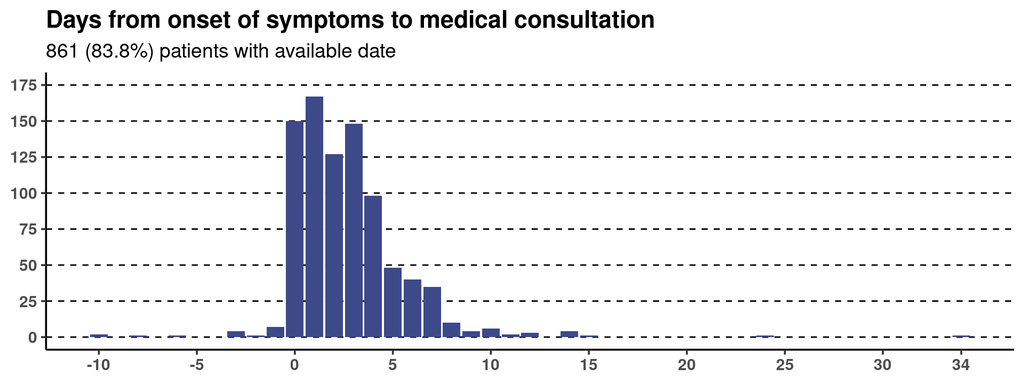

```
# A tibble: 1 × 7
  Mínimo `1o.quantil` Mediana `3o.quantil` Máximo Media Desvio.Padrão
   <dbl>        <dbl>   <dbl>        <dbl>  <dbl> <dbl>         <dbl>
1    -10            1       2            4     34  2.66          2.89
```

## Diagnóstico na primeira semana dos sintomas

```
                  Não      Sim
[1,] "Total"      "32"     "829"
[2,] "Percentual" "3.717%" "96.283%"
```

# Contato confirmado ou suspeito

```
                  Desconhecido Não      Sim
[1,] "Total"      "246"        "45"     "737"
[2,] "Percentual" "23.93%"     "4.377%" "71.693%"
```

# Sintomas

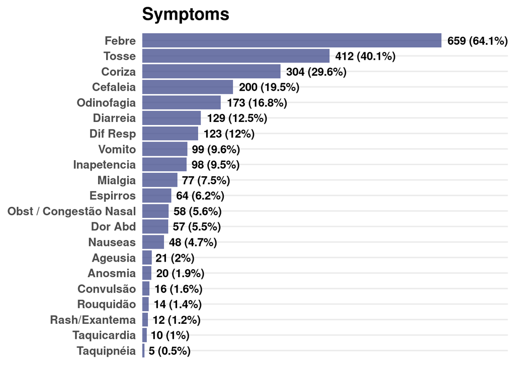

> Múltiplos sintomas:

```
                    0       1        2        3        4        5       6       7       8
[1,] "Total"        "39"    "186"    "306"    "276"    "148"    "53"    "12"    "4"     "2"
[2,] "Percentual %" "3.794" "18.093" "29.767" "26.848" "14.397" "5.156" "1.167" "0.389" "0.195"
```

```
# A tibble: 1 × 7
  Mínimo `1o.quantil` Mediana `3o.quantil` Máximo Media Desvio.Padrão
   <int>        <dbl>   <int>        <dbl>  <int> <dbl>         <dbl>
1      1            2       3            3      8  2.63          1.23
```

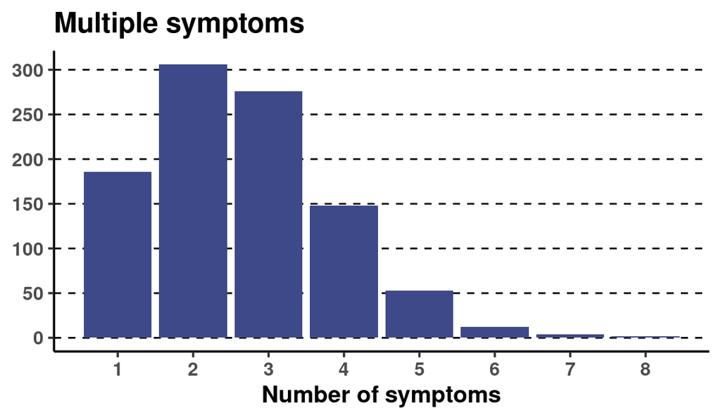

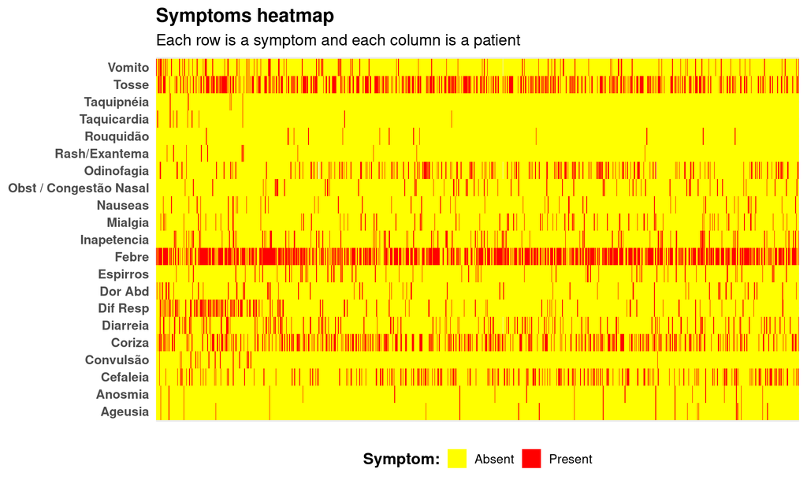

# Raio-X

```
                                                 [,1]    [,2]
                                                 "Total" "Percentual"
Normal + TQT                                     "1"     "0.097%"
Normal                                           "140"   "13.619%"
Infiltrado Instersticial                         "13"    "1.265%"
Infiltrado Instersticial + Condensação/Opacidade "1"     "0.097%"
Condensação/Opacidade                            "39"    "3.794%"
Hiperinsuflação                                  "1"     "0.097%"
Outro                                            "30"    "2.918%"
Não realizado                                    "803"   "78.113%"
```

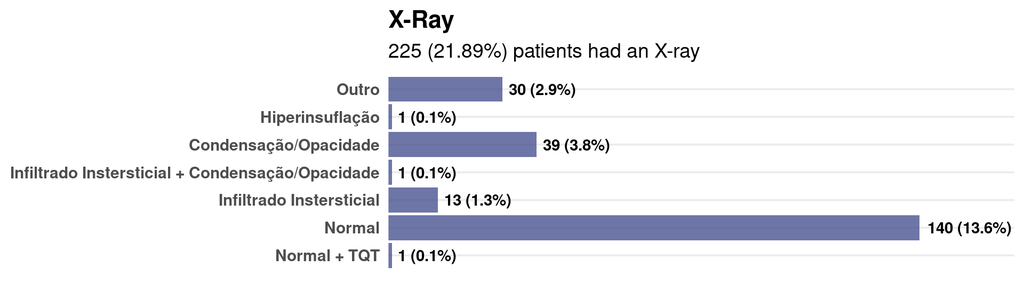

> Juntando para quatro categorias.

```
                         [,1]    [,2]
                         "Total" "Percentual"
Normal                   "141"   "13.716%"
Infiltrado Instersticial "14"    "1.362%"
Condensação/Opacidade    "39"    "3.794%"
Outro                    "31"    "3.016%"
Não realizado            "803"   "78.113%"
```

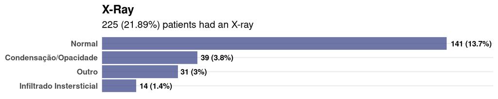

# Tomografia

```
                  Normal   Condensação/Opacidade Vidro Fosco Outro    Não realizado NR
[1,] "Total"      "19"     "9"                   "69"        "13"     "917"         "1"
[2,] "Percentual" "1.848%" "0.875%"              "6.712%"    "1.265%" "89.202%"     "0.097%"
```

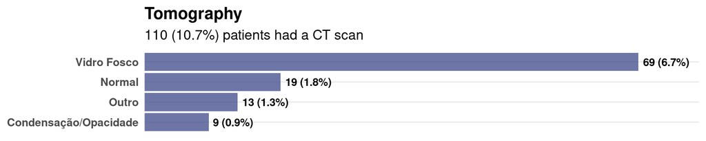

# Dímero-D

```
     Mínimo 1o.quantil Mediana    Média 3o.quantil Máximo Não realizados Desvio.Padrão
[1,]  89.31     284.74     536 1044.485     923.59  10000            855      1624.715
```

> Entre os que realizaram:

```
                  Alterado  Normal
[1,] "Total"      "94"      "79"
[2,] "Percentual" "54.335%" "45.665%"
```

```
[1] 0.2541077
```

> Diferença não significativa.

## Dímero-D por presença de comorbidade

```
# A tibble: 2 × 3
  `PRESENÇA DE COMORBIDADE` Alterado Normal
                      <dbl>    <int>  <int>
1                         0       38     47
2                         1       56     32
```

```
[1] 0.01896095
```

> Diferença significativa que aqui pode ser interpretada como interação. Nas crianças sem comorbidade é mais comum Dímero-D normal, já nas crianças com comorbidade é mais comum Dímero-D alterado. Esse *comum* se mostrou estatisticamente significativo.

# PCR

```
     Mínimo 1o.quantil Mediana    Média 3o.quantil Máximo Não realizados Desvio.Padrão
[1,]      5          5     9.2 39.37525      37.85    403            729      70.67064
```

> Entre os que realizaram:

```
                  Alterado  Normal
[1,] "Total"      "202"     "97"
[2,] "Percentual" "67.559%" "32.441%"
```

```
[1] 1.260858e-09
```

> Diferença significativa (valor-*p* < 0.0001).

## PCR por presença de comorbidade

```
# A tibble: 2 × 3
  `PRESENÇA DE COMORBIDADE` Alterado Normal
                      <dbl>    <int>  <int>
1                         0      114     67
2                         1       88     30
```

```
[1] 0.04923939
```

# VHS

```
     Mínimo 1o.quantil Mediana    Média 3o.quantil Máximo Não realizados Desvio.Padrão
[1,]      1      10.25      23 31.36567         42    130            894      27.56988
```

# Dímero-D, PCR & VHS

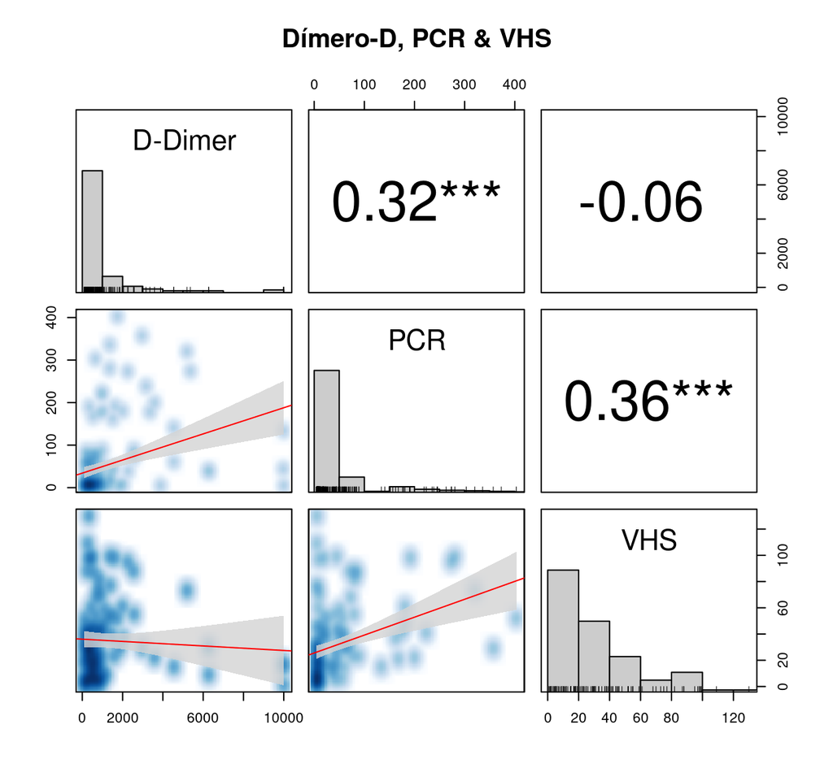

# Linfócitos

```
                  Normal    Decreased Increased Não disponível
[1,] "Total"      "175"     "118"     "8"       "727"
[2,] "Percentual" "17.023%" "11.479%" "0.778%"  "70.72%"
```

```
     Mínimo 1o.quantil Mediana    Média 3o.quantil Máximo Não realizados Desvio.Padrão
[1,]     75       1073    2048 2715.674       3562  19544            727      2274.089
```

# Neutrófilos

```
                  Normal    Decreased Increased Não disponível
[1,] "Total"      "179"     "63"      "59"      "727"
[2,] "Percentual" "17.412%" "6.128%"  "5.739%"  "70.72%"
```

```
     Mínimo 1o.quantil Mediana    Média 3o.quantil Máximo Não realizados Desvio.Padrão
[1,]     79       1968    3912 4931.147     6126.5  28677            729      4156.192
```

# Linfócitos vs. Neutrófilos

```
# A tibble: 9 × 3
  linfócitos neutrófilos     n
  <fct>      <fct>       <int>
1 Normal     Normal         99
2 Normal     Decreased      45
3 Normal     Increased      31
4 Decreased  Normal         77
5 Decreased  Decreased      14
6 Decreased  Increased      27
7 Increased  Normal          3
8 Increased  Decreased       4
9 Increased  Increased       1
```

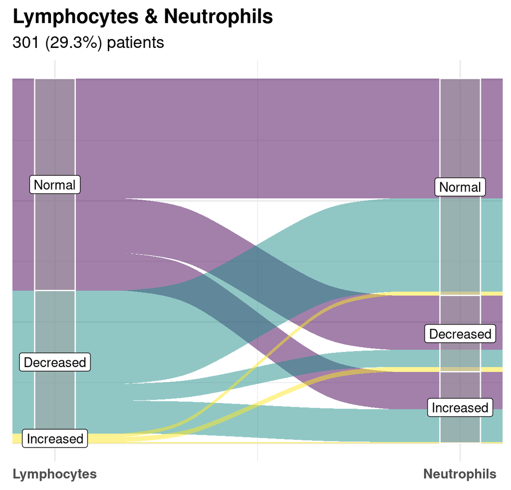

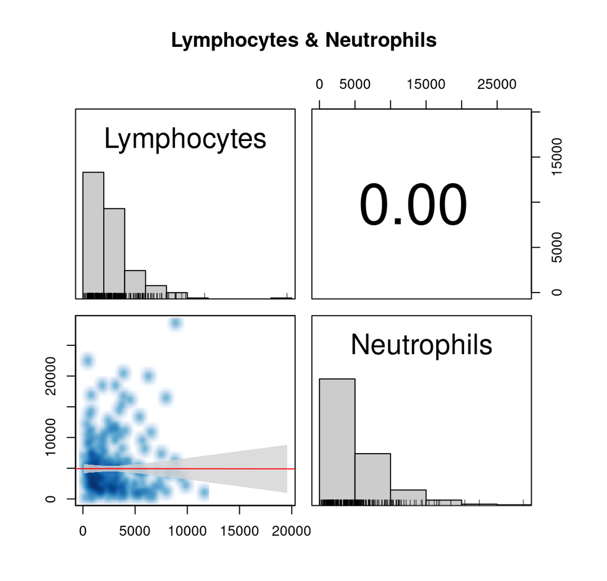

# iga, igg & igm

```
               [,1]               [,2]               [,3]
               "iga"              "igg"              "igm"
Mínimo         "46"               "16.6"             "0.6"
1o.quantil     "76"               "601.25"           "53.5"
Mediana        "99.5"             "849.5"            "82"
Média          "114.166666666667" "881.2"            "116.8"
3o.quantil     "138"              "1062.25"          "143.5"
Máximo         "221"              "2026"             "341"
Não realizados "1022"             "1020"             "1021"
Desvio.Padrão  "62.7930463241486" "638.614017116085" "112.587506707746"
```

# CV e tempo início dos sintomas

```
# A tibble: 3 × 9
  `CARGA VIRAL` Mínimo `1o.quantil` Mediana `3o.quantil` Máximo Media Desvio.Padrão     n
  <fct>          <dbl>        <dbl>   <dbl>        <dbl>  <dbl> <dbl>         <dbl> <int>
1 Alta              -8            1       2            3      8  2.06          1.89   376
2 Baixa              0            2       4            5     14  3.90          2.85   129
3 Média             -3            1       3            4     15  3.07          2.50   182
```

```
# A tibble: 3 × 2
  ` `             `valor-p`
  <chr>               <dbl>
1 Alta vs. Baixa   1.38e-10
2 Alta vs. Média   2.49e- 6
3 Baixa vs. Média  8.03e- 3
```

> Todas as diferenças médias são estatisticamente significativas (1.38e-10 = 0.000000000138, 2.49e-6 = 0.00000249 e 8.03e-3 = 0.00803).

# Referências

> A análise estatística foi realizada no ambiente de computação estatística `R` (R Core Team, 2022). Os principais pacotes `R` utilizados foram o {`dplyr`} (Wickham et al., 2022), {`tidyr`} (Wickham & Girlich, 2022), {`forcats`} (Wickham, 2021), {`lubridate`} (Grolemund & Wickham, 2011), {`ggplot2`} (Wickham, 2016), {`patckwork`} (Pedersen, 2020), {`geobr`} (Pereira & Gonçalves, 2022), {`psych`} (Revelle, 2022), e {`ggalluvial`} (Brunson & Read, 2020).

> R Core Team (2022). R: A language and environment for statistical computing. R Foundation for Statistical Computing, Vienna, Austria. URL https://www.R-project.org/

> Wickham, H., François, R., Henry, L., Müller, K. (2022). dplyr: A Grammar of Data Manipulation. R package version 1.0.9. https://CRAN.R-project.org/package=dplyr

> Wickham, H., Girlich, M. (2022). tidyr: Tidy Messy Data. R package version 1.2.0, https://CRAN.R-project.org/package=tidyr

> Wickham, H. (2021). forcats: Tools for Working with Categorical Variables (Factors). R package version 0.5.1, https://CRAN.R-project.org/package=forcats

> Grolemund, G., Wickham, H. (2011). Dates and Times Made Easy with lubridate. Journal of Statistical Software, 40(3), 1-25. https://www.jstatsoft.org/v40/i03/

> Wickham, H. (2016). ggplot2: Elegant Graphics for Data Analysis. Springer-Verlag New York

> Pedersen, T. L. (2020). patchwork: The Composer of Plots. R package version 1.1.1. https://CRAN.R-project.org/package=patchwork

> Pereira, R. H. M., Gonçalves, C. N. (2022). geobr: Download Official Spatial Data Sets of Brazil. R package version 1.6.5999, <https://github.com/ipeaGIT/geobr

> Revelle, W. (2022). psych: Procedures for Personality and Psychological Research, Northwestern University, Evanston, Illinois, USA, R package version 2.2.3. https://CRAN.R-project.org/package=psych

> Brunson, J. C., Read, Q. D. (2020). ggalluvial: Alluvial Plots in ‘ggplot2’. R package version 0.12.3. http://corybrunson.github.io/ggalluvial/